# Ecosystem Dynamics: Lab 3

## Goals for lab

- Describe the forest dynamics using a differential equation with source and sink terms
- Build a simple soil decomposition model to explore exponential decay
- Continue practicing R

## Part 1: Non-stochastic predictions

In the last two labs, you constructed a simple model of forest vegetation dynamics that predicted the growth and death of trees within a spatial domain. You also found that while the growth and death of individual trees were difficult to predict, the dynamics of the entire forest were much more predictable. In this lab, you will build on the idea of macroscopic ecosystem behavior to construct an even simpler model.

**Question 1:**

What are the inputs and outputs of the tree biomass stock in your forest model?

**Answer 1:** Inputs: npp Outputs: mortality

You can describe the macroscopic behavior of the forest using a differential equation rather than needing to simulate the growth and random death of each individual tree. A differential equation is an equation that describes the change in a ‘stock’ over time (think about a derivative that you learned in calculus). The source and sink terms are biomass transfers into or out of the stock. There can be as many source or sink terms as appropriate for the system you are modeling.

$$\frac{dB}{dt} = source - sink$$
or

$$\frac{dB}{dt} = inputs -
outputs$$

where dB is the change in vegetation biomass (gC m-2 yr-1) at time t and `dt` is the change in time (in Lab 1 and 2 dt = 1 year).

Using these ideas, you can develop a differential equation that describes the dynamics of the entire forest. The equation below includes the same NPP and mortality parameters that you used in Labs 1 and 2.

$$\frac{dB}{dt} = NPP - uB_t$$

which can be simulated in R using the following

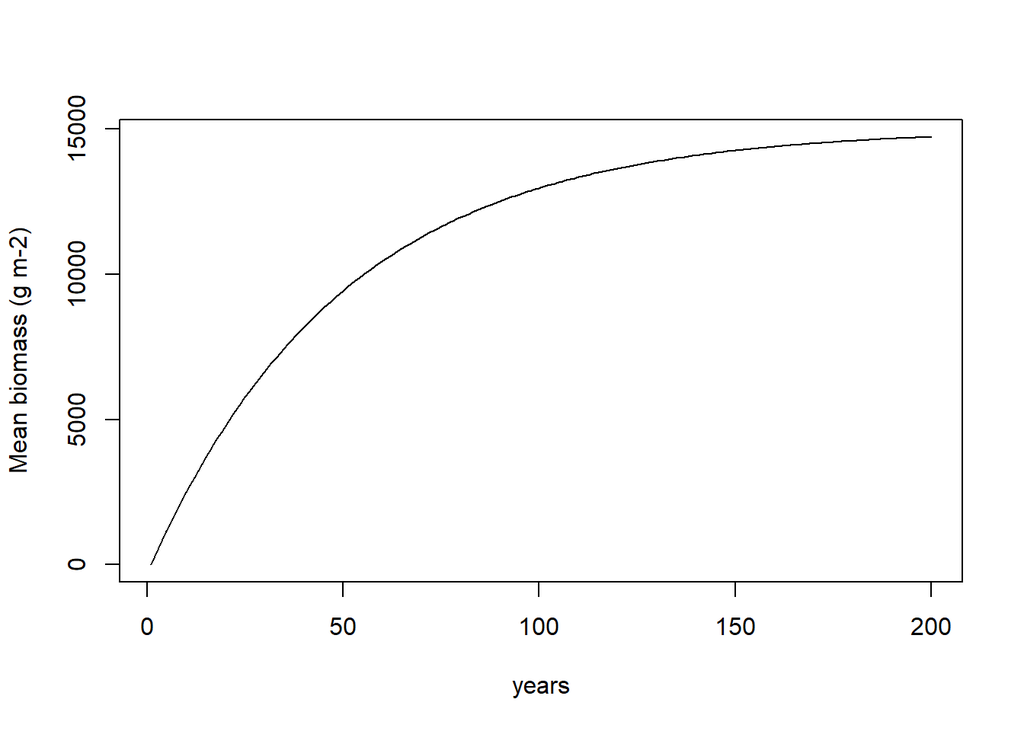

```r
simulation_years <- 200  #total number of years you want to simulate
veg <- array(NA, dim = c(simulation_years))  #creating the array to store the yearly vegetation biomass

veg[1] <- 1  #initializing the vegetation biomass in year 1 to be 1

npp <- 300  #growth rate
u <- 0.02  #mortality rate

dt <- 1 #number of years for each time step

for(i in 2:simulation_years){
  #dBdt is the derivative (Change over the time-step)
  #It adds npp and substracts a proportion of biomass that died
  dBdt <- npp - veg[i-1] * u
  #add the change to the previous year's biomass
  #note: a positive number of dBdt will add biomass, while a negative value will subtract
  #note: since dBdt is the change per year, you need to multiply
  #      it by the number of years in a time step (which is 1)
  veg[i] <- veg[i-1] + dBdt * dt
}

year <- seq(1, simulation_years, 1)
plot(year, veg, type = 'l', xlab = 'years', ylab= 'Mean biomass (g m-2)')
```

**Question 2:**

What is the difference between a stochastic and a deterministic process? Is the differential equation above stochastic or deterministic? Is the forest simulator from labs 1 and 2 stochastic or deterministic? See Soetaert and Herman Chapter 3 Section 1.

**Answer 2:** Stochastic processes often consider a degree of randomness that is attributed to the focus on an individual component/member of the system being modeling. Deterministic processes often consider the cumulative behavior/functionality of a large group of components, which have a more predictable “average” variability. The previous equation represents an deterministic process, as opposed to the stochastic models from labs 1 and 2.

**Question 3:**

How do the forest dynamics from the differential equation above compare to the dynamics of the 2x2 forest, 5x5 forest, and 50x50 forests you simulated in Lab 2? You can visually compare your plots from Lab 2 and describe the differences in text.

**Answer 3** The “smoothness” of the plot increases with the forest dimensions, until the shift to include the differential equations, where then the plot is representing a continuous function.

**Question 4:**

When do you think the differential equation approach to simulating ecosystem dynamics is appropriate rather than using a simulator that represents the growth and death of individual trees?

**Answer 4:** Differential Equations may be more useful for modeling larger populations and when more factors affecting the modeled variable are considered, such as compounding mortality or growth factors/controls. Individual models maybe be more useful when these factors are better understood/verified to real-world conditions, and on a smaller population size of largely similar individuals.

## Part 2: Simple decomposition model

Multiple differential equations can be solved simultaneously to model multiple stocks (or pools) in a forest ecosystem. Above, you have already simulated the change in a single stock, vegetation biomass, over time (`dB/dt`). We have simulated the following fluxes that we discussed in class: NPP and mortality.

To simulate Net Ecosystem Production (NEP) and total carbon storage, we need to calculate heterotrophic respiration, which is the decomposition of dead organic matter.

The simplest models of decomposition use the concept of exponential decay. Exponential decay is a proportional loss of a stock over time. For example, consider a single soil carbon pool (S):

$$\frac{dS}{dt} = -kS_t$$
where `k` is the proportion of soil carbon decomposed each year. The negative is before the `kS` because it is a sink, and the source is 0 (example lacks an input).

Using the same approach you used above to simulate the vegetation differential equation, simulate the dynamics of the soil carbon pool with an initial stock of 1000 g C m-2 and a k of 0.005 (per year). Run the simulation for 1000 years. Repeat with a k of 0.001.

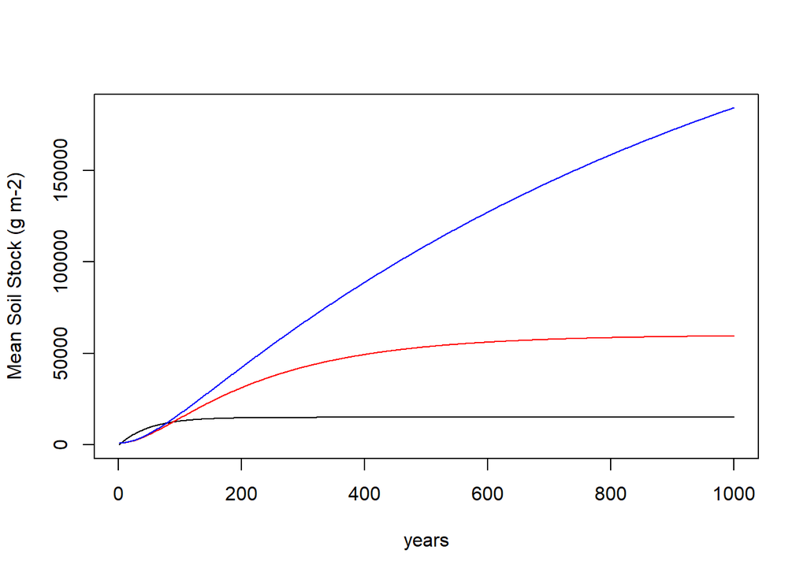

```r
simulation_years <- 1000  #total number of years you want to simulate
soil <- array(NA, dim = c(simulation_years))  #creating the array to store the yearly vegetation biomass
soil_1 <- array(NA, dim = c(simulation_years))  #creating the array to store the yearly vegetation biomass
veg <- array(NA, dim = c(simulation_years))  #creating the array to store the yearly vegetation biomass

soil[1] <- 1000  #initializing the soil stock to be 1000 g C m-2
soil_1[1] <- 1000  #initializing the soil stock to be 1000 g C m-2
veg[1] <- 1  #initializing the vegetation biomass in year 1 to be 1

u <- 0.02  #mortality rate
k <- .005 #decomposition rate
k_1 <- .001

npp <- 300  #growth rate
u <- 0.02

dt <- 1 #number of years for each time step

for(i in 2:simulation_years){

  #Growth of forest
  dBdt <- npp - veg[i-1] * u
  veg[i] <- veg[i-1] + dBdt * dt

  #Building soil stock with k = .005
  dSdt <- veg[i-1]*u - soil[i-1]*k
  soil[i] <- soil[i-1] + dSdt * dt

  #Building soil stock with k = .001
  dSdt_1 <- veg[i-1]*u - soil_1[i-1]*k_1
  soil_1[i] <- soil_1[i-1] + dSdt_1 * dt

}

year <- seq(1, simulation_years, 1)
ylimits <- range(c(veg, soil, soil_1))
plot(year, veg, type = 'l', xlab = 'years', ylab= 'Mean Soil Stock (g m-2)',  ylim = ylimits)
points(year, soil, type= 'l' , col = 'red')
points(year, soil_1, type= 'l' , col = 'blue')
```

**Question 5:**

Describe and compare the dynamics of the soil carbon pool with a k of 0.005 and a k of 0.001. Your plot should have both lines on the same figure.

**Answer 5:** A larger k of .005 vs .001 results in a lower equilibrium stock in the soil, as decomposition is greater. Greater decomposition factor results in reaching the equilibrium value sooner.

(blue is soil stock with k of .001, red is soil stock with k of .005)

**Question 6:** :

What are the units of k?

**Answer 6:** “Per unit of time”, k is a factor for the amount of decay per the unit of time.

The final step in building a simple forest ecosystem model that can predict total carbon storage is to combine the vegetation model and the soil carbon model.

$$\frac{dB}{dt} = NPP - uB_t$$
$$\frac{dS}{dt} = uB_t -kS_t$$
You will notice that the output part of the vegetation equation (i.e., mortality) is the input to the soil carbon differential equation, which links the two equations.

**Question 7:**

List all the names of the arrows in the FES textbook Figure 2.1 that are associated with the fluxes that we are modeling. Remember that we are modeling NEP using our flux equations.

**Answer 7:**

NPP (NPP): GPP, Autotrophic Respiration, Oxidation, Herbivory

Mortality (u * Bt): Herbivory, Litterfall, Death (Herbivores and of Vegetation), Herbivore excretion, exudation

Decomposition (k * St): Decomposer decomposition, Respiration of Heterotrophic Decomposers , Oxidation, Organic C export, predation on decomposers.

**Question 8:**

Draw a conceptual diagram of the model with vegetation biomass and soil carbon. Label the system’s stocks, fluxes, and domain. Define the model currency and time scale.

To answer Question 8, create a box and arrow diagram in PowerPoint, save it as an image on your hard drive, and use the following code to insert your image into R markdown.

**Answer 8:**

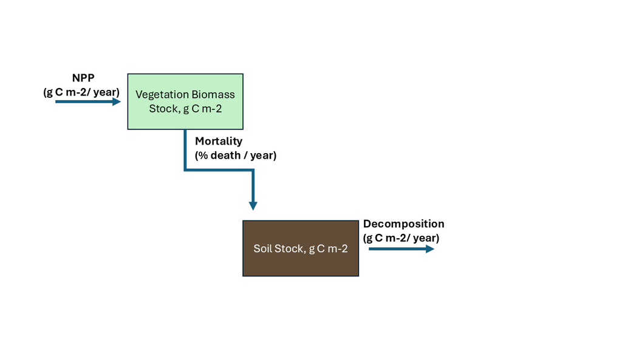

Use R to solve the set of differential equations using the same approach as above but with two stocks rather than only one. Therefore, your model will have four lines of code within the for-loop that loops over time:

- a line of code to calculate dBdt
- a line of code to calculate dSdt
- a line of code to add dBdt to the Veg previous stock
- a line to code to add dSdt the the previous soil stock.

The key is determining how to calculate dBdt and dSdt—remember that the output flux in dBdt is the input flux to dSdt.

Tip: Your solution will only have one for-loop. You will NOT have a different loop for vegetation and soil (this is a common mistake).

```r
#insert set of differential equations here that are contained in the for loop (see above)

#Growth of forest
dBdt <- npp - veg[i-1] * u
veg[i] <- veg[i-1] + dBdt * dt

#Building soil stock with k = .005
dSdt <- veg[i-1]*u - soil[i-1]*k
soil[i] <- soil[i-1] + dSdt * dt
```

**Question 9:**

What is the equilibrium carbon stock of the entire ecosystem (vegetation + soil) using the following parameter values: NPP = 300, u = 0.02, and k = 0.005; Initial vegetation = 0 and Initial soil = 0)?

**Answer 9:**

The equilibrium value for the total carbon stock approaches 75000

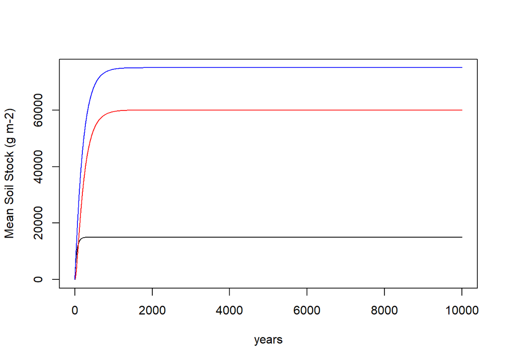

```r
simulation_years <- 10000  #total number of years you want to simulate
soil <- array(NA, dim = c(simulation_years))  #creating the array to store the yearly vegetation biomass
veg <- array(NA, dim = c(simulation_years))  #creating the array to store the yearly vegetation biomass
total <- array(NA, dim = c(simulation_years))  #creating the array to store the yearly vegetation biomass

soil[1] <- 0  #initializing the soil stock to be 1000 g C m-2
veg[1] <- 0  #initializing the vegetation biomass in year 1 to be 1
total[1] <- 1

u <- 0.02  #mortality rate
k <- .005 #decomposition rate

npp <- 300  #growth rate
u <- 0.02

dt <- 1 #number of years for each time step

for(i in 2:simulation_years){

  #Growth of forest
  dBdt <- npp - veg[i-1] * u
  veg[i] <- veg[i-1] + dBdt * dt

  #Building soil stock with k = .005
  dSdt <- veg[i-1]*u - soil[i-1]*k
  soil[i] <- soil[i-1] + dSdt * dt
  total[i] <- veg[i] + soil[i]
}

year <- seq(1, simulation_years, 1)
ylimits <- range(c(veg, soil, total))
plot(year, veg, type = 'l', xlab = 'years', ylab= 'Mean Soil Stock (g m-2)',  ylim = ylimits)
points(year, soil, type= 'l' , col = 'red')
points(year, total, type= 'l' , col = 'blue')
```

**Question 10:**

What is the change in vegetation carbon (dB/dt) and change in soil carbon (dS/dt) at equilibrium?

**Answer 10:**

at equilibrium dB/dt and dS/dt will both be 0

## Part 3: Apply model

You are charged with finding a way to double the carbon stored in a forest ecosystem. Using the model with vegetation and soils, find a parameter set (NPP, u, k) that results in a doubling of total carbon at equilibrium. Find the parameters using trial and error (i.e., just play around with parameters and decide on a set). Playing around with parameters helps build an intuition for how the model works.

**Question 11:**

Provide a plot of time vs. total carbon stocks using your new parameters.

**Answer 11:**

```r
simulation_years <- 3000  #total number of years you want to simulate
soil <- array(NA, dim = c(simulation_years))  #creating the array to store the yearly vegetation biomass
veg <- array(NA, dim = c(simulation_years))  #creating the array to store the yearly vegetation biomass
total <- array(NA, dim = c(simulation_years))  #creating the array to store the yearly vegetation biomass

soil[1] <- 0  #initializing the soil stock to be 1000 g C m-2
veg[1] <- 0  #initializing the vegetation biomass in year 1 to be 1
total[1] <- 1

u <- 0.02  #mortality rate
k <- .005 #decomposition rate

npp <- 300  #growth rate

#Scenario 2
soil_1 <- array(NA, dim = c(simulation_years))
veg_1 <- array(NA, dim = c(simulation_years))
total_1 <- array(NA, dim = c(simulation_years))

soil_1[1] <- 0
veg_1[1] <- 0
total_1[1] <- 1

u_1 <- 0.3
k_1 <- .002

npp_1 <- 300

dt <- 1 #number of years for each time step


for(i in 2:simulation_years){

  #Growth of forest

    #Scenario 1:
    dBdt <- npp - veg[i-1] * u
    veg[i] <- veg[i-1] + dBdt * dt

    #Scenario 2:
    dBdt_1 <- npp_1 - veg_1[i-1] * u_1
    veg_1[i] <- veg_1[i-1] + dBdt_1 * dt

  #Building soil stock with k = .005
  #Scenario 1:
  dSdt <- veg[i-1]*u - soil[i-1]*k
  soil[i] <- soil[i-1] + dSdt * dt
  total[i] <- veg[i] + soil[i]

  #Scenario 2:
  dSdt_1 <- veg_1[i-1]*u_1 - soil_1[i-1]*k_1
  soil_1[i] <- soil_1[i-1] + dSdt_1 * dt
  total_1[i] <- veg_1[i] + soil_1[i]
}

print(paste("Scenario 1 Equilibrium: ", total[simulation_years], "Scenario 2 Equilibrium: ", total_1[simulation_years], "Scenario 2/ Scenario 1: ", total_1[simulation_years]/total[simulation_years]))
```

```
## [1] "Scenario 1 Equilibrium:  74999.9763130498 Scenario 2 Equilibrium:  150627.188268146 Scenario 2/ Scenario 1:  2.00836314453526"
```

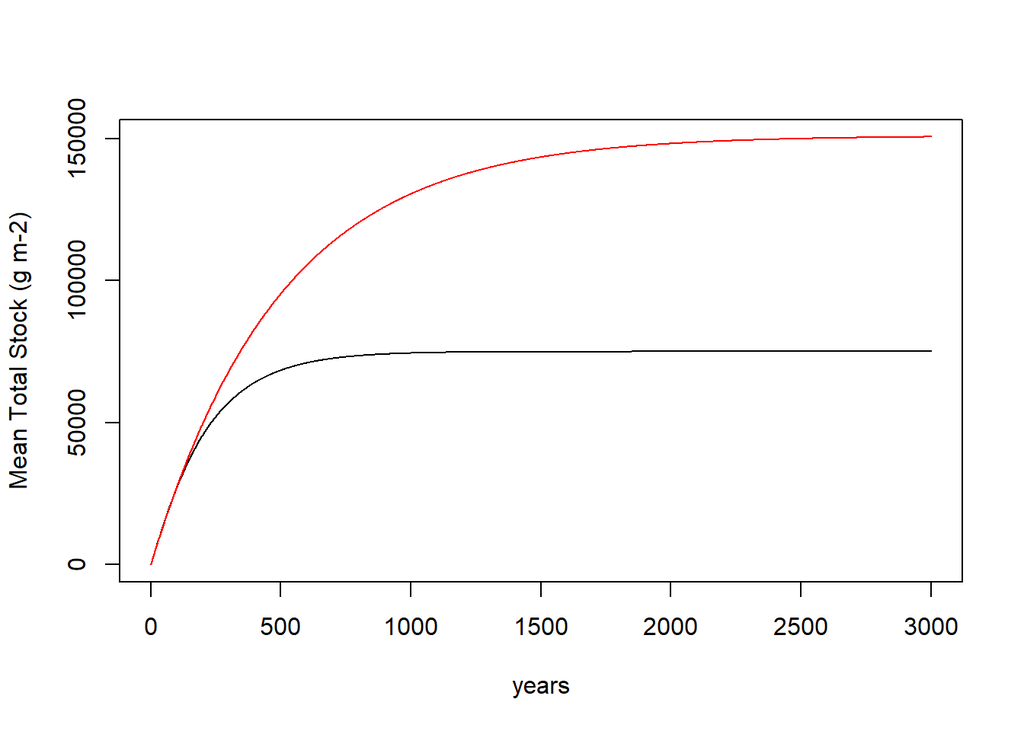

```r
year <- seq(1, simulation_years, 1)
ylimits <- range(c(total, total_1))
plot(year, total, type = 'l', xlab = 'years', ylab= 'Mean Total Stock (g m-2)',  ylim = ylimits)
points(year, total_1, type= 'l' , col = 'red')
```

**Question 12:**

How does your new set of parameters compare to the original set of parameters?

**Answer 12:** Increasing the mortality rate from .02 to .3 can reflect the increased stresses from increased inundation on trees that may not be well adapted to wetter conditions. Decreasing the decomposition rate from .005 to .002 is reflective of the flip side of these modifications, where inundation restricts oxygenation of soils and thus aerobic respiration of decomposing microbes.

**Question 13:**

The parameters that you changed are a simplified representation of actual ecosystem processes. Mechanistically, how could you potentially manage or alter the processes in the ecosystem to result in the parameter changes that you used to double the carbon?

**Answer 13:** Doubling npp would result in doubling the total forest stock, how ever this is a very unrealistic capacity for a forest manager. A more realistic adjustment would be to slow the rate of decomposition and increase the mortality rate, as is done in wetlands or bottomland forests by increasing inundation of the soils. A mortality rate of .3 and a decomposition rate of .002 results in a near perfect doubling of the equilibrium stock in the forest system.

**Question 14:**

‘…some models are useful’. How did you find this modeling exercise useful?

**Answer 14:** I found the practice of describing the role of derivatives, graphically and in equations, in ecological practice. the considerations of increasing carbon storage is the foundation of my project involving the re-wetting of the Great Dismal Swamp to retain soil and litter carbon.